# Introduction to spatial data in R

Leah A. Wasser

## Introduction

**Time:** 30 minutes

**Purpose:** In this lesson we will introduce some of the key concepts associated with spatial data including:

- Spatial extent
- Resolution
- Coordinate reference system

We will also define raster vs. vector data structures.

**Background:** Often we need to use spatial data in our analysis - that is data that correspond to some x,y (and z) location on the Earth. however, not all spatial data are created the same. understanding the basic foundations of working with spatial data will save you a lot of time when it comes to processing the data in tools like R, QGIS and python!

### Learning outcomes

At the end of this 30 minute overview you will be able to:

1. Explain the difference between the raster vs vector data structures.
2. Define spatial extent, resolution, coordinate reference system.
3. List the 3 vector data structures (point, line, polygon).
4. List 2-3 `R` packages that can be used to work with spatial data.

## Getting started with R

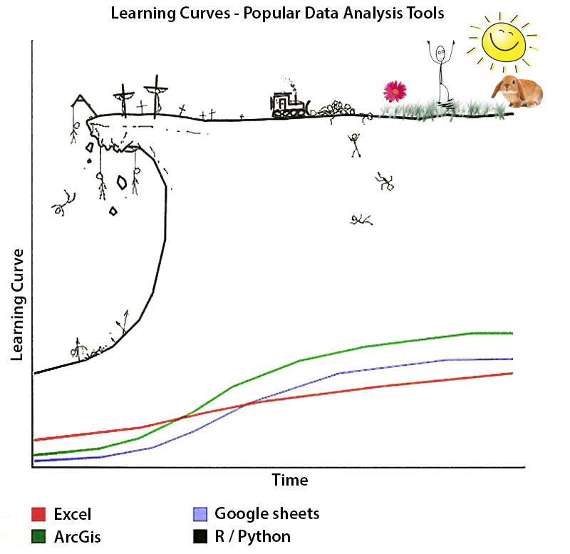

the R / Python learning curve

## Why R for GIS - the power of automation

It may be a bit of extra effort at the beginning to learn a tool like R. However, the payoff is large once you learn the basic skills to support task automation.

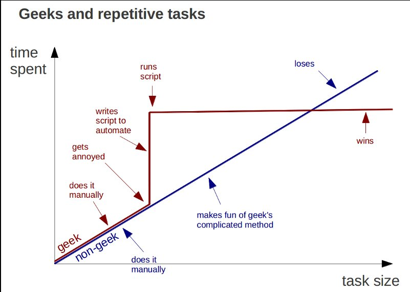

Geeks and automation

Specific to spatial data, R allows you to:

- Create automated data cleaning workflows that crop, reproject, convert data formats across many, large datasets (Leah’s example from the data institute last year)
- Repeat workflows over and over without having to step through tasks
- Repeat select portions of a workflow over and over if need be
- Add new / updated data to your workflow easily if the processing workflow is robust (e.g. timeseries data)
- Create figures that can be updated easily
- Document your workflow to remind your future self (think you in 3 months or if you’re me - tomorrow :) ) about the steps that you took to implement your workflow
- Create POWERFUL data-driven reports that include not only static plots but INTERACTIVE (e.g. leaflet)

In this lesson we are going to learn the basics of working with spatial data in R. Some of you may think this is the boring stuff - however understanding these concepts will allow you to do just about anything that you want with spatial data in R!

## About vector data

[Intro to vector data - EarthDataScience.org](https://earthdatascience.org/courses/earth-analytics/spatial-data-r/intro-vector-data-r/)

Attributes of vector data

- Discrete geometric locations
- x,y locations are vertices
- Organization of those vertices determines structure: points, lines, polygons

[figure not shown]

Vector data types - points, lines and polygons

## Vector data formats

There are many different spatial vector data formats. Let’s list a few:

- shapefile
- geojson
- text files
- others??

## Vector data spatial extent

The spatial extent of a vector **dataset** is determined by the min and max x,y location of ALL OF THE SPATIAL OBJECTS stored in the dataset.

NOTE: the spatial extent of an individual object can also be quantified!

[figure not shown]

About vector data extent

### Vector data attributes

Vector data often has associated attribute tables. When in a shapefile format, these look like excel spreadsheets where each object has an associated set of attributes.

[figure not shown]

Attribute tables

in a geojson structure this may look like this:

```xml
[ {
  "station_name" : "SOUTH PLATTE RIVER AT COOPER BRIDGE NEAR BALZAC",
  "amount" : "262.00",
  "flag" : "na",
  "station_status" : "Gage temporarily anavailable",
  "county" : "MORGAN",
  "wd" : "1",
  "dwr_abbrev" : "PLABALCO",
  "data_source" : "Co. Division of Water Resources",
  "http_linkage" : {
    "url" : "http://www.dwr.state.co.us/SurfaceWater/data/detail_graph.aspx?ID=PLABALCO&MTYPE=DISCHRG"
  },
  "div" : "1",
  "date_time" : "2017-02-15T09:00:00",
  "stage" : "1.86",
  "usgs_station_id" : "06759910",
  "variable" : "DISCHRG",
  "location" : {
    "latitude" : "40.357498",
    "needs_recoding" : false,
    "longitude" : "-103.528053"
  },
  "station_type" : "Stream"
}
...
]
```

## Coordinate reference systems - how spatial data line up

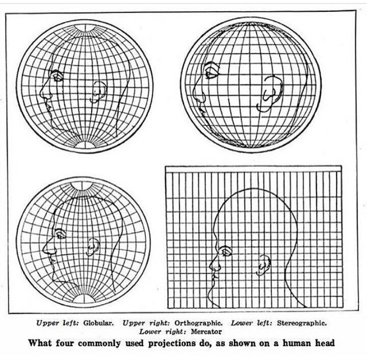

The human head projected

## Components of a CRS

The coordinate reference system is made up of several key components:

- **Coordinate System:** the X, Y grid upon which our data is overlayed and how we define where a point is located in space.
- **Horizontal and vertical units:** The units used to define the grid along the x, y (and z) axis.
- **Datum:** A modeled version of the shape of the earth which defines the origin used to place the coordinate system in space. We will explain this further, below.
- **Projection Information:** the mathematical equation used to flatten objects that are on a round surface (e.g. the earth) so we can view them on a flat surface (e.g. our computer screens or a paper map).

### CRS storage formats

- EPSG
- proj.4
- WKT
- others!!!

#### Other CRS resources

- [Video about datums, ellipsoids and geoids ~8mins](https://www.youtube.com/watch?v=Z41Dt7_R180)
- [Video explaining various datums ~3mins](https://www.youtube.com/watch?v=xKGlMp__jog)
- [Coordinate Reference Systems - 101 - Earthdatascience.org](https://earthdatascience.org/courses/earth-analytics/spatial-data-r/intro-to-coordinate-reference-systems/)
- [Get to know EPSG, WKT and other CRS definition structures - EarthDataScience.org](https://earthdatascience.org/courses/earth-analytics/spatial-data-r/understand-epsg-wkt-and-other-crs-definition-file-types/)

## About raster data

About raster data:

- data are stored in a **regular grid**
- a value is associated with each grid cell (also called a pixel)
- each pixel represents a geographic area - in our case that is often an area on the earth

[Open raster data in R - earthdatascience.org website](https://earthdatascience.org/courses/earth-analytics/lidar-raster-data-r/open-lidar-raster-r/)

[figure not shown]

About raster data

### Raster resolution

- The size of each pixel is referred to as **resolution**
- If pixels are smaller (represent a smaller area on the earth, they are considered HIGHER resolution) - in the example of an image, this makes the image look more ‘crisp’
- if you have fewer pixels within a particular spatial extent, the resolution is LOWER
- if you have more pixels within a particular spatial extent, the resolution is HIGHER

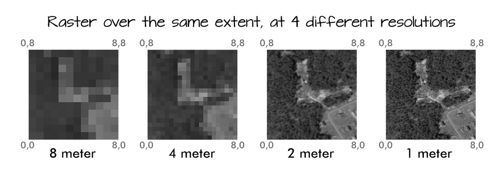

Raster resolution

[figure not shown]

Raster pixel resolution

### Raster spatial extent

The spatial extent of a raster refers to the area on the earth’s surface that the raster covers.

[figure not shown]

Raster spatial extent

Note that the raster spatial extent relates directly to the spatial resolution.

## CHALLENGE questions

1. If you have more pixels over the same spatial extent - will the image look sharper (more clear) or more blurry?
2. If you have fewer pixels over the same spatial extent…

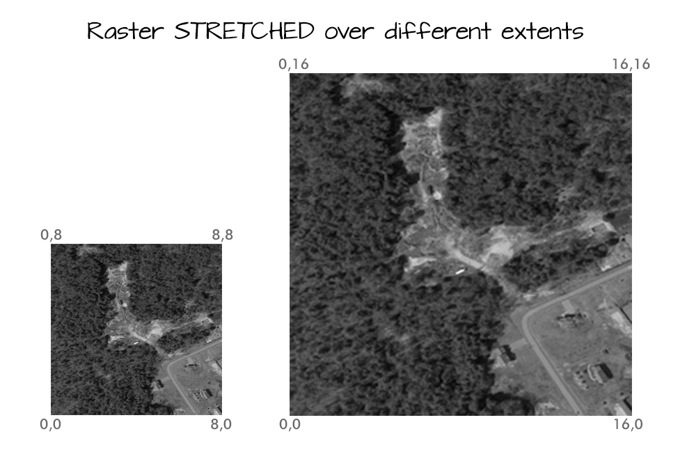